# Lab: Random Effects

36-600

Today’s lab will be relatively short, so that you can turn it in and head off to fall break.

## Data

Here we read in the sleep study data from Project 1 and we retain three variables: `cohort` and `term_gpa` as predictors, and `TotalSleepTime` (renamed `sleep`) as the response.

```r
suppressMessages(library(tidyverse))
df        <- read.csv(url("https://www.stat.cmu.edu/~pfreeman/cmu-sleep.csv"))
df$cohort <- factor(df$cohort)
df %>% select(.,cohort,TotalSleepTime,term_gpa) -> df
names(df)[2] <- "sleep"
summary(df)
```

```
##   cohort        sleep          term_gpa
##  lac1:131   Min.   :194.8   Min.   :0.350
##  lac2: 77   1st Qu.:366.9   1st Qu.:3.233
##  nh  :147   Median :400.4   Median :3.556
##  uw1 :140   Mean   :397.3   Mean   :3.450
##  uw2 :139   3rd Qu.:430.1   3rd Qu.:3.810
##             Max.   :587.7   Max.   :4.000
```

Note that in this lab, we are not going to split the data into training and test sets.

## Question 1

Let’s first assume that we regress `sleep` upon `cohort`. Since the cohorts that appear in the study are a randomly selected subset of all possible cohorts, pursuing learning a random effects model is appropriate (as opposed to a one-way ANOVA model). Learn an appropriate model using `lmer()` and pass the output to `summary()`. Display the five intercepts for the five cohorts. (Hint: utilize one of the functions shown in the notes, one specifically used with the Palmer Penguin data.) Last, what is the within-cohort correlation? (This last part involves extracting numbers from the `summary()` output and “doing math” as opposed to making further function calls.) Is this a weak, medium, or strong correlation? (Use the internet to make that judgement. Note that no two tables mapping correlation coefficients to adjectives seem to match.)

```r
suppressMessages(library(lme4))  # uncomment once the library is installed

# FILL ME IN WITH CODE
model <- lmer(sleep ~ 1 + (1 | cohort), data = df)
summary(model)
```

```
## Linear mixed model fit by REML ['lmerMod']
## Formula: sleep ~ 1 + (1 | cohort)
##    Data: df
##
## REML criterion at convergence: 6747.1
##
## Scaled residuals:
##     Min      1Q  Median      3Q     Max
## -4.3441 -0.6160  0.0175  0.6454  3.7001
##
## Random effects:
##  Groups   Name        Variance Std.Dev.
##  cohort   (Intercept)  205.7   14.34
##  Residual             2429.7   49.29
## Number of obs: 634, groups:  cohort, 5
##
## Fixed effects:
##             Estimate Std. Error t value
## (Intercept)   395.93       6.72   58.91
```

```r
coef(model)$cohort
```

```
##      (Intercept)
## lac1    391.9559
## lac2    381.1778
## nh      385.9503
## uw1     411.6616
## uw2     408.9144
```

```r
variance_components <- as.data.frame(VarCorr(model))
cohort_variance <- variance_components[1, "vcov"]
residual_variance <- attr(VarCorr(model), "sc")^2

# Calculate within-cohort correlation (ICC)
icc <- cohort_variance / (residual_variance)
icc
```

```
## [1] 0.08464209
```

[output not shown]

## Question 2

Now let’s look at `term_gpa`. Learn a simple linear regression model that has `sleep` as the response variable and `term_gpa` as the predictor variable, and overlay the model on a plot of `sleep` versus `term_gpa`. Also, determine the AIC value for the model.

```r
# FILL ME IN WITH CODE

# Fit the simple linear regression model
lm_model <- lm(sleep ~ term_gpa, data = df)

# Display the summary of the model
summary(lm_model)
```

```
##
## Call:
## lm(formula = sleep ~ term_gpa, data = df)
##
## Residuals:
##      Min       1Q   Median       3Q      Max
## -153.773  -31.975    3.135   31.587  182.478
##
## Coefficients:
##             Estimate Std. Error t value Pr(>|t|)
## (Intercept)  326.627     13.800  23.668  < 2e-16 ***
## term_gpa      20.494      3.959   5.176 3.04e-07 ***
## ---
## Signif. codes:  0 '***' 0.001 '**' 0.01 '*' 0.05 '.' 0.1 ' ' 1
##
## Residual standard error: 49.85 on 632 degrees of freedom
## Multiple R-squared:  0.04067,    Adjusted R-squared:  0.03916
## F-statistic:  26.8 on 1 and 632 DF,  p-value: 3.043e-07
```

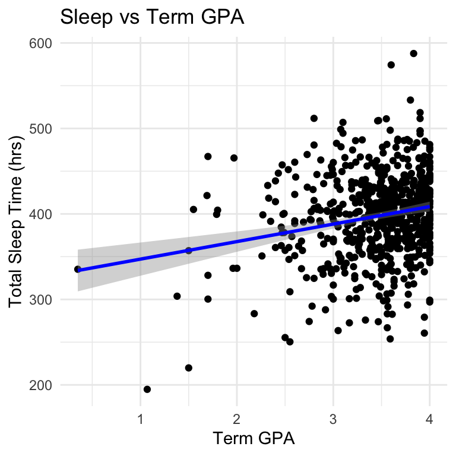

```r
# Create the plot with ggplot
ggplot(df, aes(x = term_gpa, y = sleep)) +
  geom_point() +  # Scatter plot of the data
  geom_smooth(method = "lm", col = "blue") +  # Regression line
  labs(title = "Sleep vs Term GPA", x = "Term GPA", y = "Total Sleep Time (hrs)") +
  theme_minimal()
```

```r
# Calculate AIC for the linear regression model
AIC(lm_model)
```

```
## [1] 6759.875
```

## Question 3

Now implement a mixed effects model with `term_gpa` as the fixed effect and `cohort` as the random effect, with random intercepts (but same slopes). Output the linear model coefficients for each cohort. (Mentally confirm that indeed, the intercepts are different but the slopes are the same.) And, as you did in Q2, record the AIC value.

No plot is necessary, for now.

```r
# FILL ME IN WITH CODE
# Fit the mixed effects model
mixed_model <- lmer(sleep ~ term_gpa + 1 | cohort, data = df)

# Display the summary of the model
summary(mixed_model)
```

[output not shown]

```r
# Extract random intercepts for each cohort
random_effects <- coef(mixed_model)$cohort

# Calculate the AIC for the mixed effects model
AIC(mixed_model)
```

```
## [1] 6726.309
```

```r
random_effects
```

```
##      term_gpa (Intercept)
## lac1 12.88511    350.2807
## lac2 33.95218    262.4901
## nh   49.97494    202.4131
## uw1  19.98949    342.2349
## uw2  23.77817    329.6761
```

## Question 4

Repeat Q3, but now have random slopes with the same intercept.

```r
# FILL ME IN WITH CODE
# Fit the mixed effects model with random slopes for term_gpa
mixed_model_random_slopes <- lmer(sleep ~ term_gpa +( 0 + term_gpa | cohort), data = df)

# Display the summary of the model
summary(mixed_model_random_slopes)
```

```
## Linear mixed model fit by REML ['lmerMod']
## Formula: sleep ~ term_gpa + (0 + term_gpa | cohort)
##    Data: df
##
## REML criterion at convergence: 6705.9
##
## Scaled residuals:
##     Min      1Q  Median      3Q     Max
## -3.1467 -0.6384  0.0161  0.6801  3.6836
##
## Random effects:
##  Groups   Name     Variance Std.Dev.
##  cohort   term_gpa   20.05   4.478
##  Residual          2293.67  47.892
## Number of obs: 634, groups:  cohort, 5
##
## Fixed effects:
##             Estimate Std. Error t value
## (Intercept)  315.424     13.575  23.236
## term_gpa      23.436      4.387   5.342
##
## Correlation of Fixed Effects:
##          (Intr)
## term_gpa -0.881
```

```r
# Extract random slopes and intercept for each cohort
random_effects_slopes <- coef(mixed_model_random_slopes)$cohort

# Calculate the AIC for the mixed effects model with random slopes
AIC(mixed_model_random_slopes)
```

```
## [1] 6713.929
```

```r
random_effects_slopes
```

```
##      (Intercept) term_gpa
## lac1    315.4243 22.91726
## lac2    315.4243 19.08337
## nh      315.4243 19.45821
## uw1     315.4243 27.62375
## uw2     315.4243 28.09606
```

## Question 5

Repeat Q3, but now have random slopes *and* intercepts.

```r
# FILL ME IN WITH CODE
# Fit the mixed effects model with random slopes and intercepts for term_gpa
mixed_model_random_slopes_intercepts <- lmer(sleep ~ term_gpa + (term_gpa | cohort), data = df)

# Display the summary of the model
summary(mixed_model_random_slopes_intercepts)
```

```
## Linear mixed model fit by REML ['lmerMod']
## Formula: sleep ~ term_gpa + (term_gpa | cohort)
##    Data: df
##
## REML criterion at convergence: 6702
##
## Scaled residuals:
##     Min      1Q  Median      3Q     Max
## -3.3004 -0.6271 -0.0078  0.6573  3.6963
##
## Random effects:
##  Groups   Name        Variance Std.Dev. Corr
##  cohort   (Intercept) 2668.7   51.66
##           term_gpa     128.4   11.33    -0.97
##  Residual             2267.2   47.62
## Number of obs: 634, groups:  cohort, 5
##
## Fixed effects:
##             Estimate Std. Error t value
## (Intercept)  296.802     27.484   10.80
## term_gpa      28.456      6.602    4.31
##
## Correlation of Fixed Effects:
##          (Intr)
## term_gpa -0.967
```

```r
# Extract random slopes and intercepts for each cohort
random_effects_slopes_intercepts <- coef(mixed_model_random_slopes_intercepts)$cohort

# Calculate the AIC for the mixed effects model with random slopes and intercepts
AIC(mixed_model_random_slopes_intercepts)
```

```
## [1] 6713.963
```

```r
random_effects_slopes_intercepts
```

```
##      (Intercept) term_gpa
## lac1    332.4752 18.29695
## lac2    261.7015 34.15287
## nh      234.3221 41.29623
## uw1     330.5430 23.33440
## uw2     324.9693 25.19796
```

## Question 6

Select the best model from among those in Q2-Q5 (i.e., the one with the lowest AIC value). Plot the data again, and overlay the best model…note that this may require you to make five separate calls to `geom_abline()`. Note that to access the slopes and intercepts, you would use, e.g.,

```
coefs <- coef(lmer.out)$cohort
coefs[1,1] # first row, first column -- intercept of first cohort
coefs[3,2] # third row, second column -- slope of third cohort
etc.
```

In the end, your plot may not show five separate lines, which is fine, because the `lac1` and `lac2`, and `uw1` and `uw2`, cohorts had very similar data.

```r
# FILL ME IN WITH CODE
aic_q2 <- AIC(lm_model)  # from Q2
aic_q3 <- AIC(mixed_model)  # from Q3
aic_q4 <- AIC(mixed_model_random_slopes)  # from Q4
aic_q5 <- AIC(mixed_model_random_slopes_intercepts)  # from Q5

# Create a data frame of AIC values for comparison
aic_values <- data.frame(
  Model = c("Q2: Linear Regression",
            "Q3: Mixed Effects (Random Intercepts)",
            "Q4: Mixed Effects (Random Slopes)",
            "Q5: Mixed Effects (Random Slopes and Intercepts)"),
  AIC = c(aic_q2, aic_q3, aic_q4, aic_q5)
)

# Identify the best model with the lowest AIC
best_model <- aic_values[which.min(aic_values$AIC), ]
best_model
```

```
##                               Model      AIC
## 3 Q4: Mixed Effects (Random Slopes) 6713.929
```

```r
# Get the coefficients (intercepts and slopes) from the best model (from Q4)
coefs <- coef(mixed_model_random_slopes)$cohort

# Example: accessing intercept and slope for different cohorts
# coefs[row, column] -> row is cohort, column 1 is intercept, column 2 is slope
coefs[1,1]  # intercept of the first cohort
```

```
## [1] 315.4243
```

```r
coefs[3,2]  # slope of the third cohort
```

```
## [1] 19.45821
```

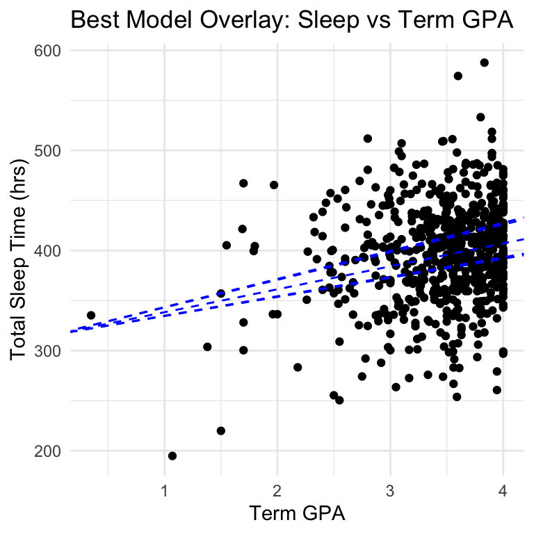

```r
# Plot the original data (sleep vs term_gpa)
plot <- ggplot(df, aes(x = term_gpa, y = sleep)) +
  geom_point() +  # Scatter plot of the data
  labs(title = "Best Model Overlay: Sleep vs Term GPA",
       x = "Term GPA",
       y = "Total Sleep Time (hrs)") +
  theme_minimal()

# Overlay regression lines for each cohort
# We loop through each cohort and add the corresponding abline (slope and intercept)
for (i in 1:nrow(coefs)) {
  plot <- plot +
    geom_abline(intercept = coefs[i, 1], slope = coefs[i, 2], color = "blue", linetype = "dashed")
}

# Display the final plot
plot
```